# Analiza wyników studentów

## Wstęp

Badany zbiór jest źródłem informacji na temat uczniów i ich ocen z róznych przedmiotów. W naszej analizie postaramy się zrozumieć oraz zobrazować relacje między wynikami studentów a ich innymi cechami.

[figure not shown]

Badany zbiór danych jest fikcyjny i pochodzi ze strony *[kaggle.com](https://www.kaggle.com/datasets/spscientist/students-performance-in-exams?fbclid=IwAR2mgaWkdEd0aRKPPoUbOk2_QoRR-0uOxNsOTTieOuNIhz8MIbHpnEIpKMM)*.

## Zmienne liczbowe

Zbiór danych na jakim będziemy pracować zawiera procentowe wyniki studentów z trzech różnych egzaminów:

- wyniki testu z matematyki (math.score),
- wyniki testu z rozumienia tekstu czytanego (reading.score),
- wyniki testu z pisania (writing.core).

## Zmienne liczbowe - struktura danych

Podstawowe statystyki opisowe wyników z poszczególnych egzaminów:

```
   math.score     reading.score    writing.score
 Min.   :  0.00   Min.   : 17.00   Min.   : 10.00
 1st Qu.: 57.00   1st Qu.: 59.00   1st Qu.: 57.75
 Median : 66.00   Median : 70.00   Median : 69.00
 Mean   : 66.09   Mean   : 69.17   Mean   : 68.05
 3rd Qu.: 77.00   3rd Qu.: 79.00   3rd Qu.: 79.00
 Max.   :100.00   Max.   :100.00   Max.   :100.00
```

## Zmienne kategoryczne

Zbiór cechują także następujące zmienne kategoryczne:

- płeć (gender),
- rasa/przynależność etniczna (race/ethnicity),
- wykształcenie rodziców (parental level of education),
- rodzaj spożywanego lunchu (lunch),
- ukończenie testu przygotowującego do egzaminów (test preparation course).

## Zmienne kategoryczne - struktura danych

```
    gender    race.ethnicity     parental.level.of.education
 female:518   group A: 89    associate's degree:222
 male  :482   group B:190    bachelor's degree :118
              group C:319    high school       :196
              group D:262    master's degree   : 59
              group E:140    some college      :226
                             some high school  :179
```

```
          lunch     test.preparation.course
 free/reduced:355   completed:358
 standard    :645   none     :642
```

## Badanie zupełności zbioru danych

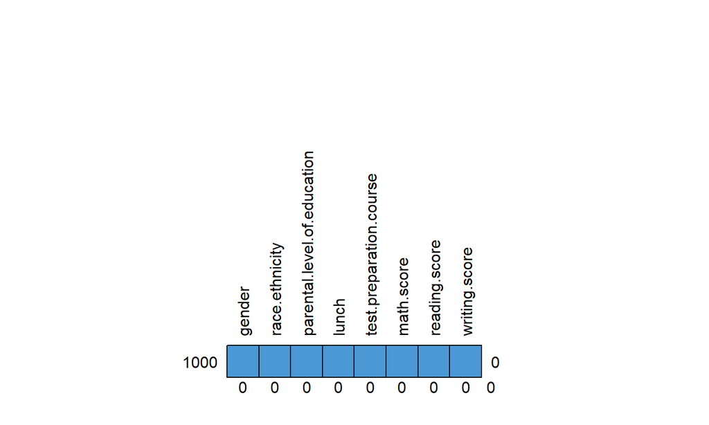

Stwierdzamy, że nasz zbiór nie posiada informacyjnych braków.

## Graficzna prezentacja wyników

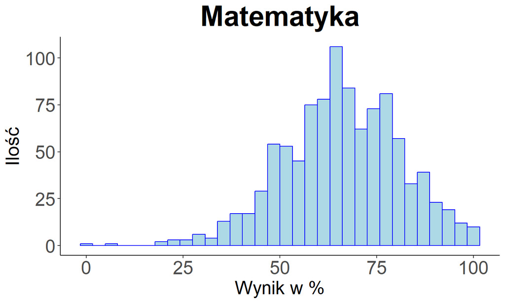

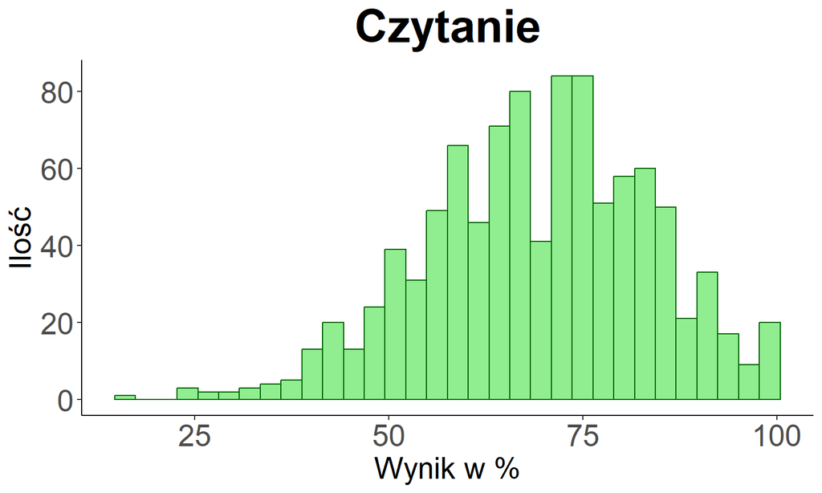

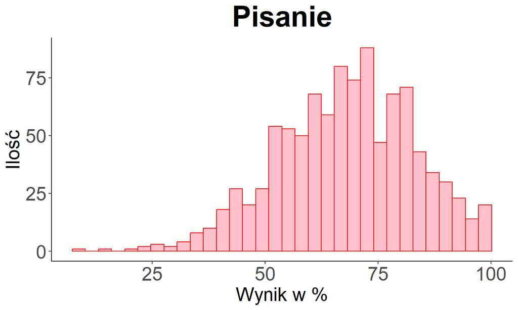

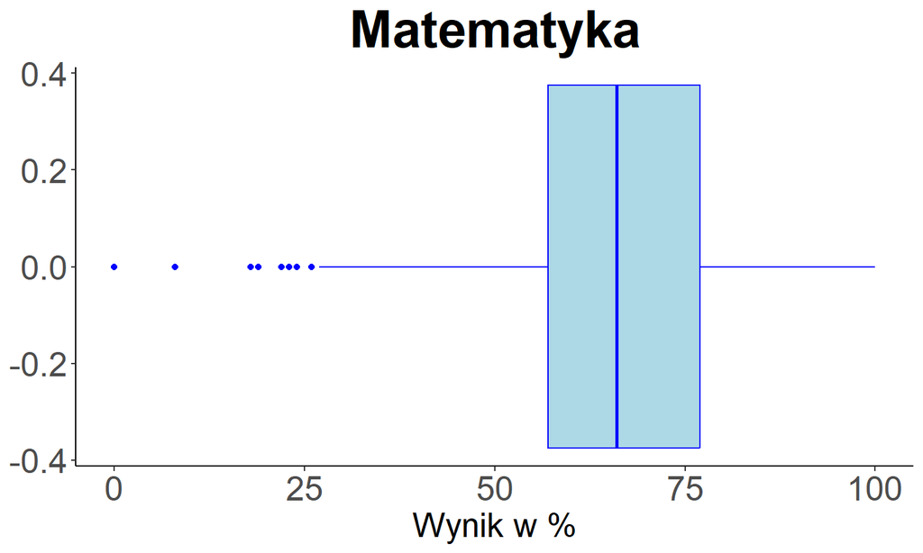

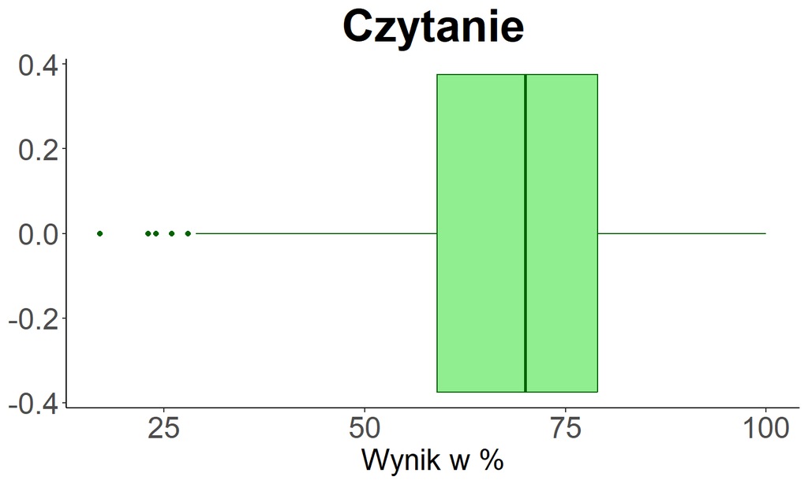

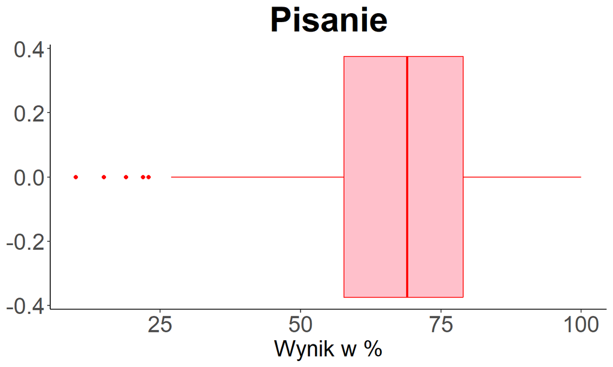

Zauważamy, że każda ze zmiennych liczbowych posiada rozkład zbliżony do normalnego.

## Dalsza analiza rozkładów wyników

Badanie symetryczności i kurtozy:

- rozkład wyników z matematyki - As=-0.279, Kurt.=0.268,
- rozkład wyników z czytania - As=-0.259, Kurt.=-0.074,
- rozkład wyników z pisania - As=-0.289, Kurt.=-0.039.

Stwierdzamy więc, że każdy rozkład jest skośny lewostronnie, posiada lewy ogon. Każdy z nich z wyjątkiem wyników z matematyki - której wykres jest leptokurtyczny - posiada rozkład platykurtyczny.

## Związki między wynikami

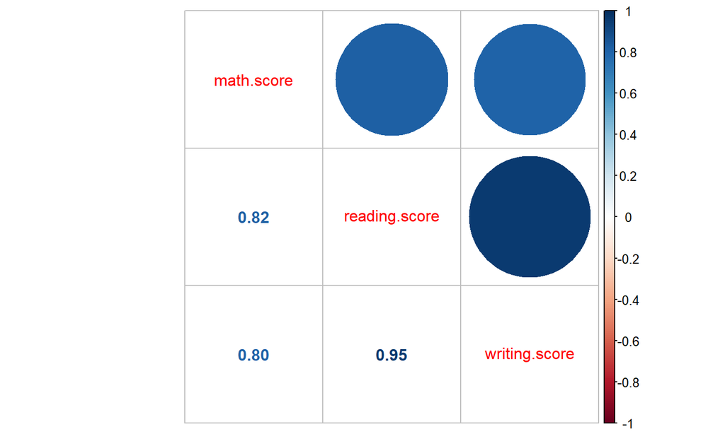

Na podstawie zbadania korelacji Pearsona zauważamy, że każda ze zmiennych numerycznych jest ze sobą silnie związana. Oznacza to, iż możemy się spodziewać, że uczeń, któremu idzie dobrze (źle) nauka jednego przedmiotu, osiąga także dobre (mierne) wyniki w pozostałych.

## Porównanie wyników z matematyki ze statystykami kategorycznymi

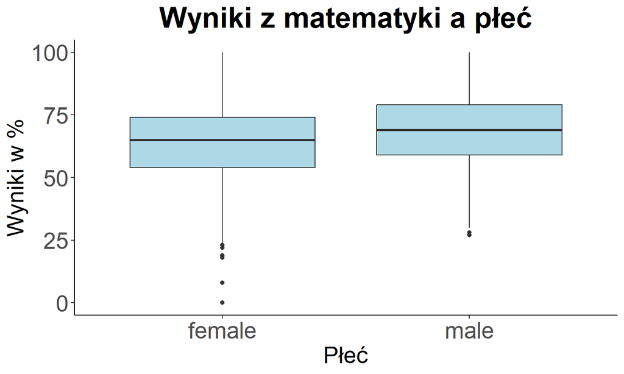

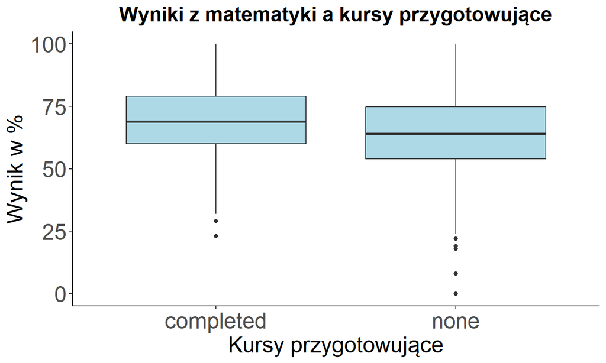

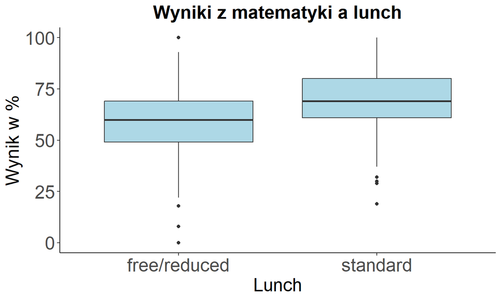

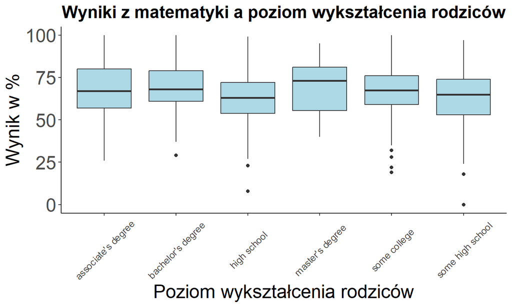

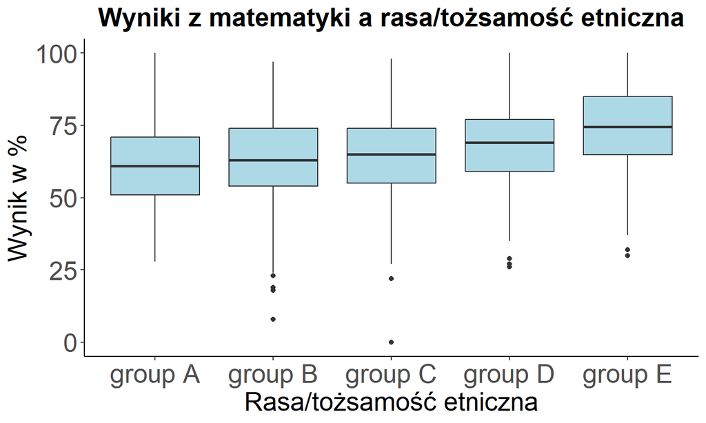

## Porównanie wyników z czytania ze statystykami kategorycznymi

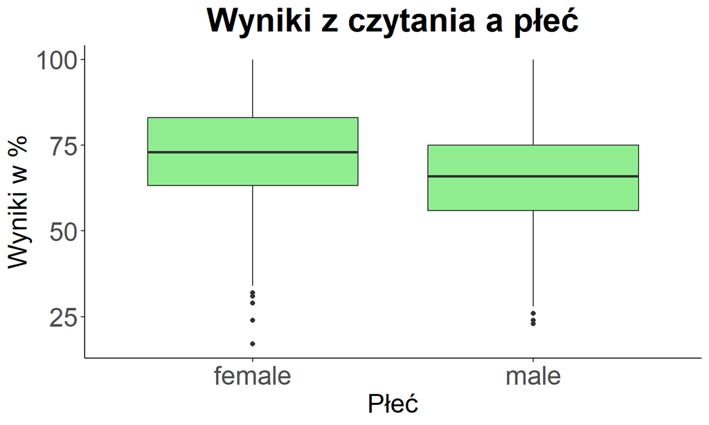

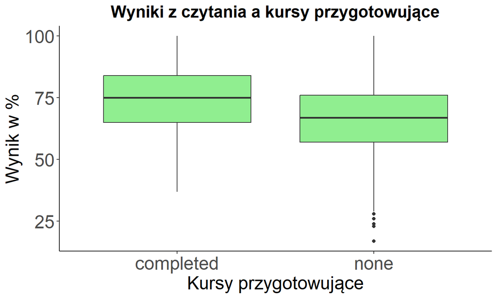

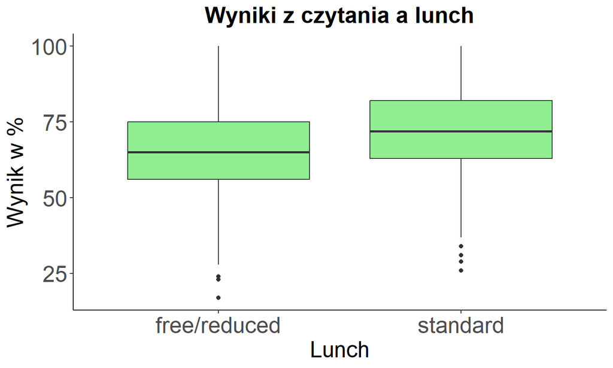

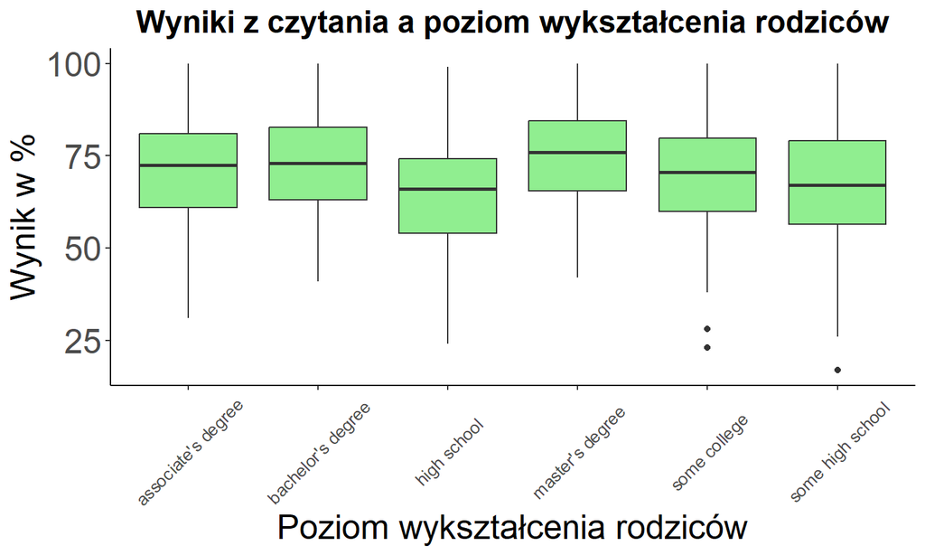

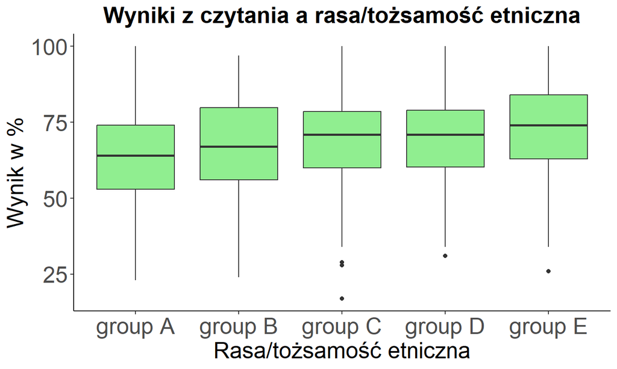

## Porównanie wyników z pisania ze statystykami kategorycznymi

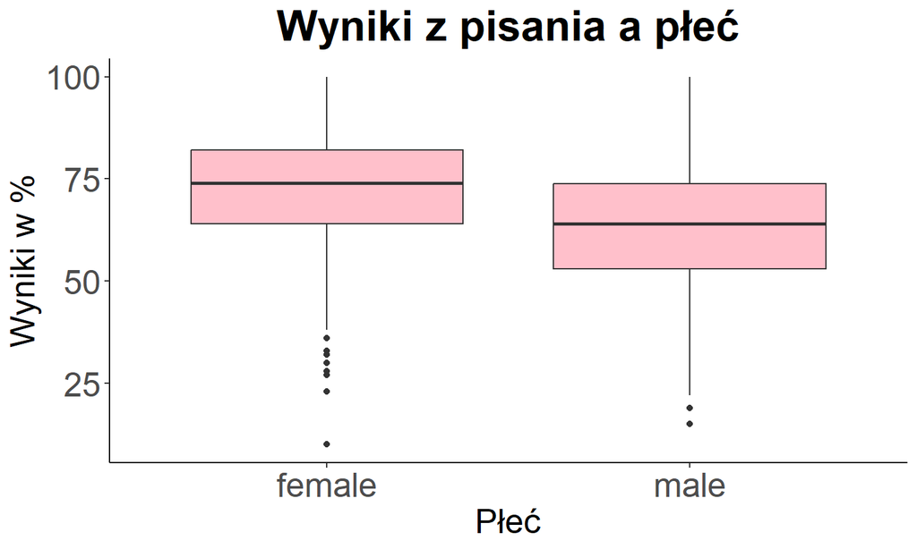

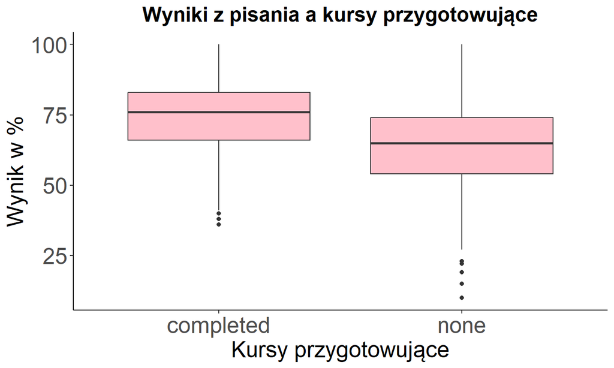

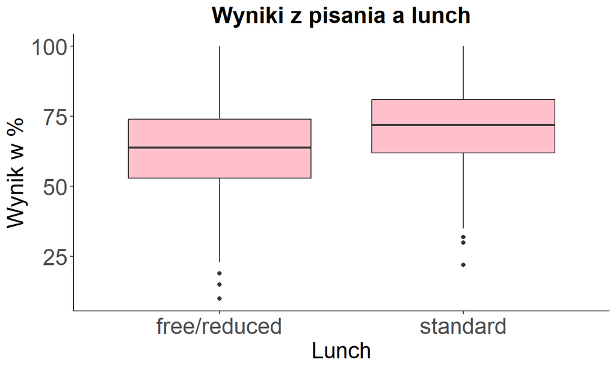

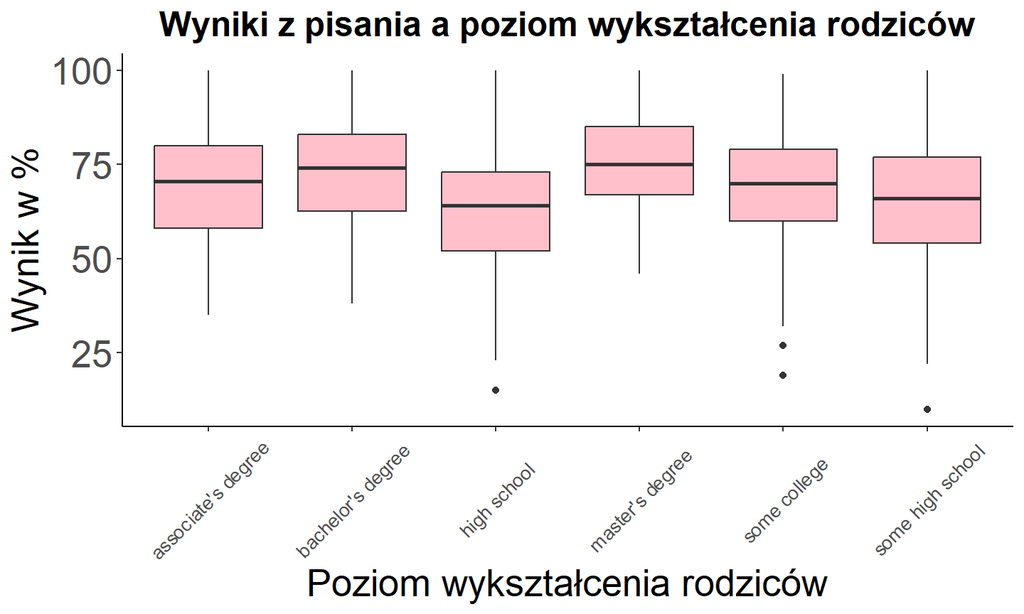

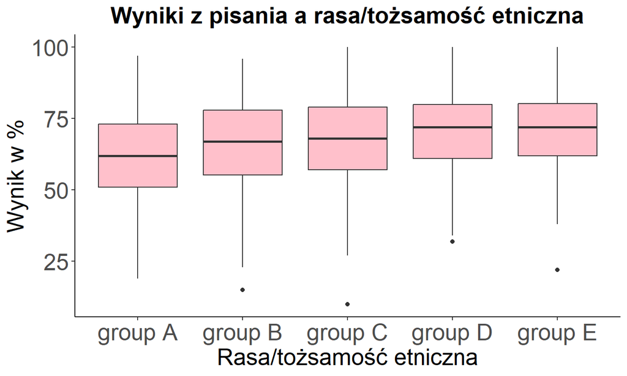

## Wnioski dotyczące porównania wyników z cechami

Przeciętnie, najlepsze oceny z matematyki otrzymali chłopcy, jednak z czytania i pisania lepiej poradziły sobie dziewczynki. Ponadto, dzieci, które zjadały pełen lunch, także osiągały przeciętnie lepsze wyniki niż te, jedzące darmowy lub pomniejszony. Najlepiej we wszystkich testach wypadły dzieci rodziców z wykształceniem wyższym na poziomie magistra. Przeciętnie też, lepiej wypadają dzieci, które przeszły przez kurs przygotowujący. W każdym przypadku grupa E przeciętnie wypadła najlepiej, zaś grupa A najgorzej.

## Drzewa klasyfikacyjne i regresyjne

Jak podaje strona *[Pogotowia Statystycznego](https://www.statsoft.pl/textbook/stathome_stat.html?https%3A%2F%2Fwww.statsoft.pl%2Ftextbook%2Fstcart.html)*:

> “Modele drzew klasyfikacyjnych i regresyjnych (Classification and Regression Trees - C&RT) umożliwia [*sic!*] zarówno budowę modeli służących do rozwiązywania problemów regresyjnych (gdzie zmienną zależną jest cecha ilościową) jak i klasyfikacyjnych (jakościowa zmienna zależna).”

W naszym projekcie postaramy się wytłumaczyć wyniki z poszczególnych przedmiotów za pomocą danych kategorycznych.

## Wstępny opis i uzasadnienie

Z drzew klasyfikacyjnych i regresyjnych (ang. classification and regression trees - CART). Korzystamy w sytuacji kiedy zależność między zmiennymi objaśniającymi i objaśnianymi nie jest liniowa, a raczej niezwykle skomplikowana. Drzewa decyzyjne korzystają z tzw. predyktorów, mają one za zadanie przewidywać wartości zmiennej, którą staramy się opisać za ich pomocą. Każdy kolejny węzęł w powstałym drzewie stanowi najważniejszy (najistotniejszy, pozwala przewidzieć w najogólniej) sposób podziału danych w rozważanym zakresie. Liście drzewa zawierają informacje o przeciętnych wynikach w grupie spełniającej wszystkie warunki umieszczone na ścieżce do korzenia.

## Metoda

1. Rekurencyjnie rozbijamy dane na mniejsze kategorie, by stworzyć duże drzewo. W tym celu wybieramy punkt dla predyktora, w którym RSS (Residual Standard Error) będzie najmnejszy. W tym punkcie dzielimy dane na dwa zbiory i postępujemy tak do momentu, aż każdy zbiór będzie miał pewną ustaloną minimalną ilość elementów.
2. Stosujemy ocenę złożoności w celu zmniejszenia lub przystrzyżenia uzyskanego dużego drzewa, jako funkcję α. W tym celu dla każdego drzewa z T liśćmi szukamy tego, które minimalizuje RSS + α(T).
3. Możemy zastosować sprawdzian krzyżowy (k-fold cross validation) w celu znalezienia wartości α, która minimalizuje błąd testowy.
4. Wybieramy ostateczny model.

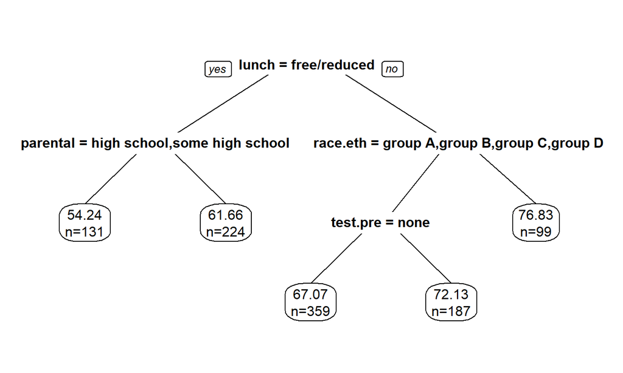

## Informacje na temat drzewa cd.

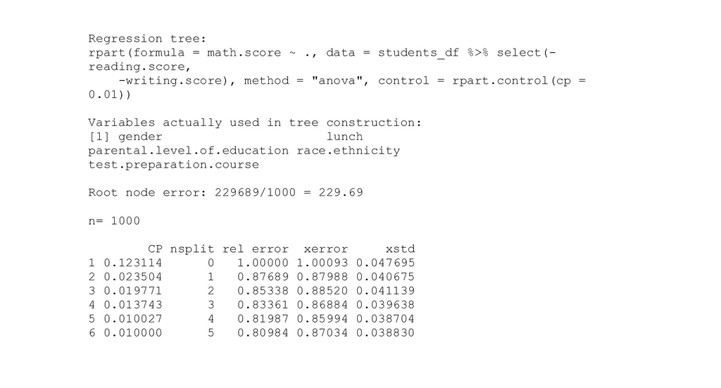

```r
printcp(tree)
```

## Informacje na temat drzewa cd.

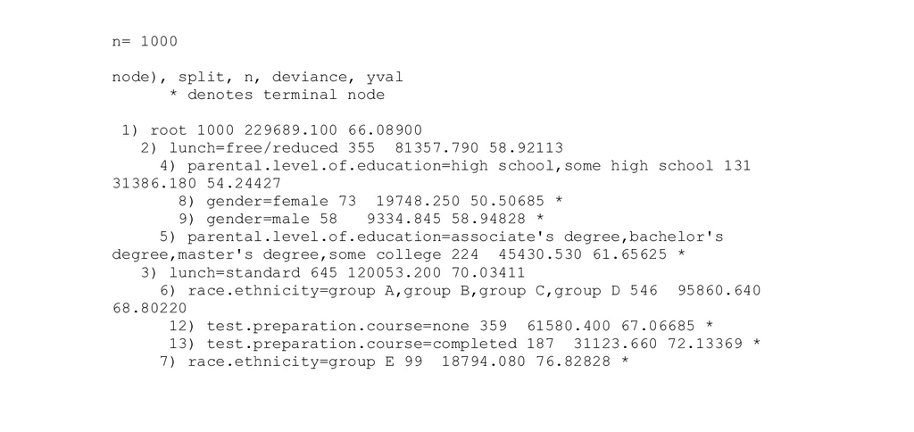

```r
print(tree)
```

## Informacje na temat drzewa cd.

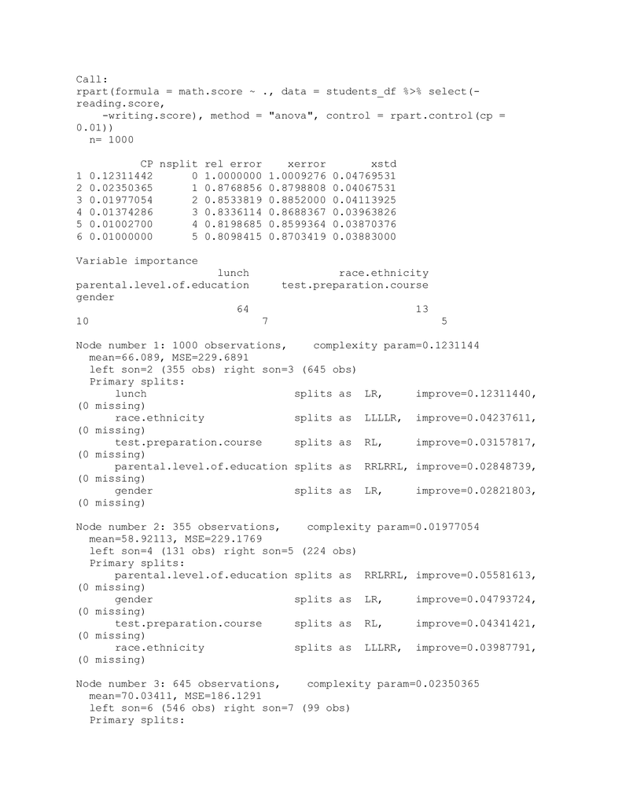

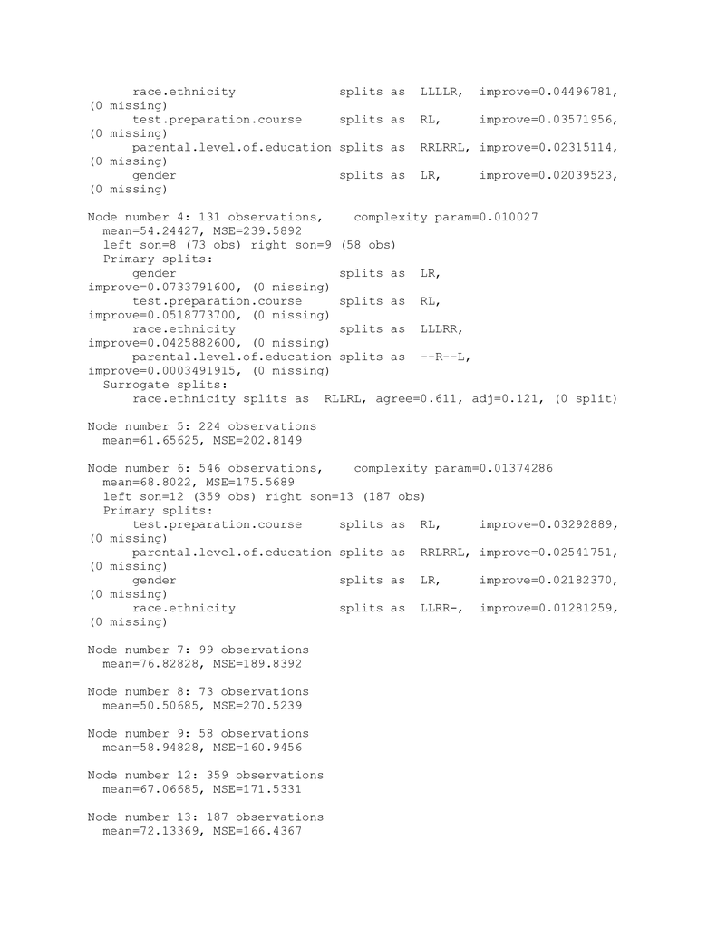

```r
summary(tree)
```

## Bibliografia

1. https://www.kaggle.com/datasets/spscientist/students-performance-in-exams?fbclid=IwAR2mgaWkdEd0aRKPPoUbOk2_QoRR-0uOxNsOTTieOuNIhz8MIbHpnEIpKMM
2. https://www.statsoft.pl/textbook/stathome_stat.html?https%3A%2F%2Fwww.statsoft.pl%2Ftextbook%2Fstcart.html
3. https://www.statology.org/classification-and-regression-trees-in-r/
4. https://www.statology.org/classification-and-regression-trees/
5. https://www.statology.org/k-fold-cross-validation/